# Week 12 Independent_project

Ayub Bett

1/26/2022

## R Markdown

##Defining the Question a) Specifying the Question We are tasked with cleaning the dataset and finding patterns within it by performing EDA

2. Defining the metrics of success This project will be considered a success when we have found patterns and visualized them where necessary.
3. Understanding the context A Kenyan entrepreneur has created an online cryptography course and would want to advertise it on her blog. She currently targets audiences originating from various countries. In the past, she ran ads to advertise a related course on the same blog and collected data in the process. She would now like to employ your services as a Data Science Consultant to help her identify which individuals are most likely to click on her ads.
4. experimental design taken
1. Load the dataset
2. Clean the dataset.
3. perform Exploratory data analysis

```r
#installing packages


library(data.table)
#
#Loading the dataset
advert_df1 <- fread("http://bit.ly/IPAdvertisingData")

#Previewing the first 6 rows
head(advert_df1)
```

```
##    Daily Time Spent on Site Age Area Income Daily Internet Usage
## 1:                    68.95  35    61833.90               256.09
## 2:                    80.23  31    68441.85               193.77
## 3:                    69.47  26    59785.94               236.50
## 4:                    74.15  29    54806.18               245.89
## 5:                    68.37  35    73889.99               225.58
## 6:                    59.99  23    59761.56               226.74
##                            Ad Topic Line           City Male    Country
## 1:    Cloned 5thgeneration orchestration    Wrightburgh    0    Tunisia
## 2:    Monitored national standardization      West Jodi    1      Nauru
## 3:      Organic bottom-line service-desk       Davidton    0 San Marino
## 4: Triple-buffered reciprocal time-frame West Terrifurt    1      Italy
## 5:         Robust logistical utilization   South Manuel    0    Iceland
## 6:       Sharable client-driven software      Jamieberg    1     Norway
##              Timestamp Clicked on Ad
## 1: 2016-03-27 00:53:11             0
## 2: 2016-04-04 01:39:02             0
## 3: 2016-03-13 20:35:42             0
## 4: 2016-01-10 02:31:19             0
## 5: 2016-06-03 03:36:18             0
## 6: 2016-05-19 14:30:17             0
```

```r
#Checking the datatypes
str(advert_df1)
```

```
## Classes 'data.table' and 'data.frame':   1000 obs. of  10 variables:
##  $ Daily Time Spent on Site: num  69 80.2 69.5 74.2 68.4 ...
##  $ Age                     : int  35 31 26 29 35 23 33 48 30 20 ...
##  $ Area Income             : num  61834 68442 59786 54806 73890 ...
##  $ Daily Internet Usage    : num  256 194 236 246 226 ...
##  $ Ad Topic Line           : chr  "Cloned 5thgeneration orchestration" "Monitored national standardization" "Organic bottom-line service-desk" "Triple-buffered reciprocal time-frame" ...
##  $ City                    : chr  "Wrightburgh" "West Jodi" "Davidton" "West Terrifurt" ...
##  $ Male                    : int  0 1 0 1 0 1 0 1 1 1 ...
##  $ Country                 : chr  "Tunisia" "Nauru" "San Marino" "Italy" ...
##  $ Timestamp               : POSIXct, format: "2016-03-27 00:53:11" "2016-04-04 01:39:02" ...
##  $ Clicked on Ad           : int  0 0 0 0 0 0 0 1 0 0 ...
##  - attr(*, ".internal.selfref")=<externalptr>
```

```r
#Finding the total number of missing values in each column
colSums(is.na(advert_df1))
```

```
## Daily Time Spent on Site                      Age              Area Income
##                        0                        0                        0
##     Daily Internet Usage            Ad Topic Line                     City
##                        0                        0                        0
##                     Male                  Country                Timestamp
##                        0                        0                        0
##            Clicked on Ad
##                        0
```

```r
#We notice that there are no missing values in the dataset
```

```r
#Finding duplicated entries within the dataset
duplicated_rows <- advert_df1[duplicated(advert_df1),]

#Printing out the duplicated entries
duplicated_rows
```

```
## Empty data.table (0 rows and 10 cols): Daily Time Spent on Site,Age,Area Income,Daily Internet Usage,Ad Topic Line,City...
```

```r
#Similarly there are no duplicated entries
```

##Checking for outliers

```r
#Checking for outliers using boxplot
library(dplyr)
data_num2 <- select_if(advert_df1, is.numeric)
data_num2
```

```
##       Daily Time Spent on Site Age Area Income Daily Internet Usage Male
##    1:                    68.95  35    61833.90               256.09    0
##    2:                    80.23  31    68441.85               193.77    1
##    3:                    69.47  26    59785.94               236.50    0
##    4:                    74.15  29    54806.18               245.89    1
##    5:                    68.37  35    73889.99               225.58    0
##   ---
##  996:                    72.97  30    71384.57               208.58    1
##  997:                    51.30  45    67782.17               134.42    1
##  998:                    51.63  51    42415.72               120.37    1
##  999:                    55.55  19    41920.79               187.95    0
## 1000:                    45.01  26    29875.80               178.35    0
##       Clicked on Ad
##    1:             0
##    2:             0
##    3:             0
##    4:             0
##    5:             0
##   ---
##  996:             1
##  997:             1
##  998:             1
##  999:             0
## 1000:             1
```

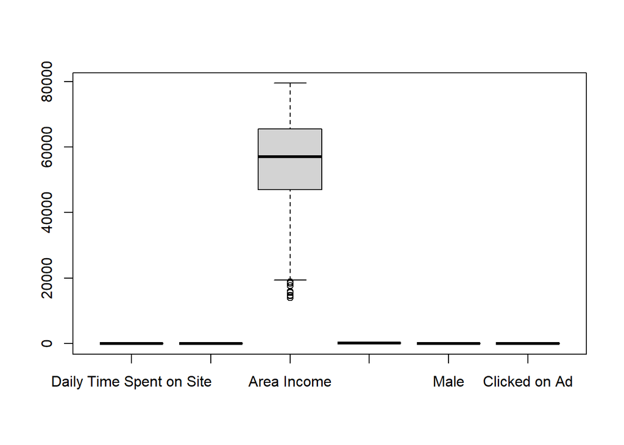

```r
boxplot(data_num2)
```

```r
#We notice that outliers are only available in the Area income column, but since they represent income from certain areas we fail to drop them
```

##Exploratory Data Analysis ##Univariate Analysis #Measures of Central Tendency

```r
#Finding the mean of the numerical columns
advert_mean1 <- mean(advert_df1$`Daily Time Spent on Site`)
advert_mean2 <- mean(advert_df1$Age)
advert_mean3 <- mean(advert_df1$`Area Income`)
advert_mean4 <- mean(advert_df1$`Daily Internet Usage`)

#Printing out the results for daily time spent on site
advert_mean1
```

```
## [1] 65.0002
```

```r
#Printing results for Age
advert_mean2
```

```
## [1] 36.009
```

```r
#Printing the results for Area income
advert_mean3
```

```
## [1] 55000
```

```r
#Printing results for daily internet usage
advert_mean4
```

```
## [1] 180.0001
```

```r
#
```